# Individual Project

Zhijiao Chen

2020/4/15

# Individual Project

### Part One: Data Visualization

The time series I’m going to analyze is S&P/Case-Shiller MA-Boston Home Price Index. Since it is a seasonally adjusted time series, there’s no seasonality in this time series.

```
S&P/Case-Shiller MA-Boston Home Price Index

Source: S&P Dow Jones Indices LLC

Release: S&P/Case-Shiller Home Price Indices

Units:  Index Jan 2000=100, Seasonally Adjusted

Frequency:  Monthly
```

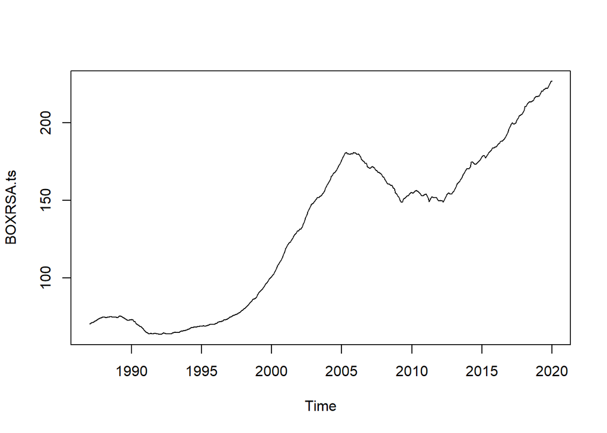

```r
plot(BOXRSA.ts)
```

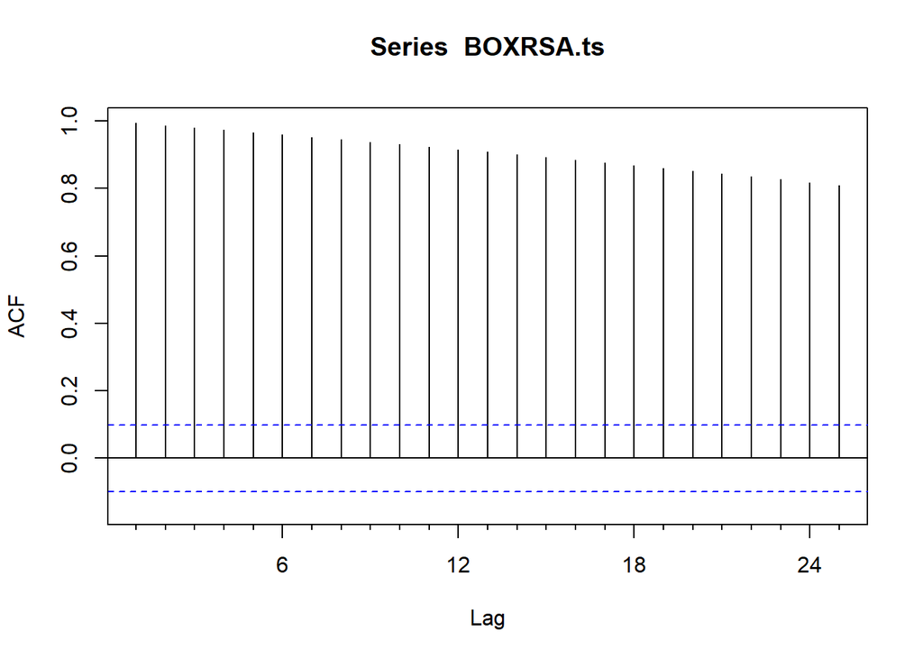

```r
Acf(BOXRSA.ts)
```

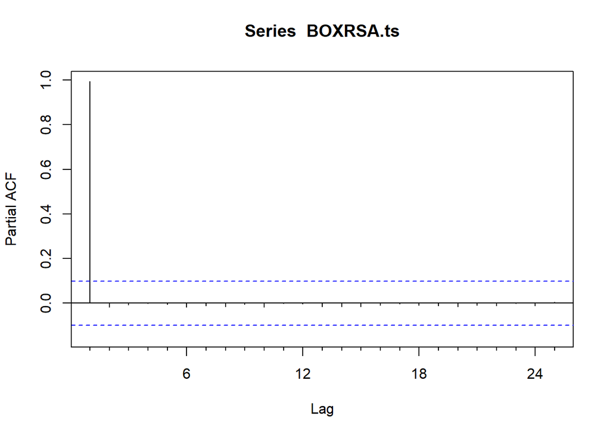

```r
Pacf(BOXRSA.ts)
```

From Figure 2 and Figure 3, we can see that ACF decays slowly while PACF drops rapidly. Note that the PACF plot has a significant spike only at lag 1. We can see a very obvious trend in this Seasonally Adjusted data.

### Part Two: Splitting the data

For this topic, I care about a long term trend of Boston Home Price Index. When dealing with these topics, a train/validation structure is better, and I can predict for a period of time. So I chose use a train/validation structure.

I split the whole time series into two parts: Training part (From 1987-01 to 2013-12) and validation part (From 2014-01 to 2020-01).

```r
BOXRSA.trend <- tslm(BOXRSA.ts ~ trend)
# set train and validation
BOXRSA.train <- window(BOXRSA.ts,end=c(2013,12))
BOXRSA.valid <- window(BOXRSA.ts,start=c(2014,1))
nValid <- length(BOXRSA.valid)
```

### Part Three: ARIMA model

ARIMA is a very popular technique for time series modelling. It describes the correlation between data points and takes into account the difference of the values.

First of all, I ran a Dickey-Fuller test to see whether the time series is stationary or not. Since the null hypothesis cannot be rejected, so random walk plus drift exists, which make sense given that there is a growth rate. So I add a first difference and use an ARIMA model. The model with only one order of differencing assumes a constant average trend–it is essentially a fine-tuned random walk model with growth–and it, therefore, makes relatively conservative trend projections.

```r
# ADF test on unit root data, use the auto lag selection feature with the BIC
df.test <- ur.df(BOXRSA.ts,type="trend",selectlags="BIC")
print("trend ADF test")
```

```
## [1] "trend ADF test"
```

```r
print(summary(df.test))
```

```
##
## ###############################################
## # Augmented Dickey-Fuller Test Unit Root Test #
## ###############################################
##
## Test regression trend
##
##
## Call:
## lm(formula = z.diff ~ z.lag.1 + 1 + tt + z.diff.lag)
##
## Residuals:
##      Min       1Q   Median       3Q      Max
## -2.28199 -0.28007  0.01623  0.29376  3.15042
##
## Coefficients:
##               Estimate Std. Error t value Pr(>|t|)
## (Intercept)  0.1409406  0.1037537   1.358   0.1751
## z.lag.1     -0.0021999  0.0017366  -1.267   0.2060
## tt           0.0013889  0.0007715   1.800   0.0726 .
## z.diff.lag   0.6680707  0.0375536  17.790   <2e-16 ***
## ---
## Signif. codes:  0 '***' 0.001 '**' 0.01 '*' 0.05 '.' 0.1 ' ' 1
##
## Residual standard error: 0.6206 on 391 degrees of freedom
## Multiple R-squared:  0.4692, Adjusted R-squared:  0.4651
## F-statistic: 115.2 on 3 and 391 DF,  p-value: < 2.2e-16
##
##
## Value of test-statistic is: -1.2668 6.0104 2.2671
##
## Critical values for test statistics:
##       1pct  5pct 10pct
## tau3 -3.98 -3.42 -3.13
## phi2  6.15  4.71  4.05
## phi3  8.34  6.30  5.36
```

```r
sumStats <- summary(df.test)
#Third statistic since type = 'trend'
teststat <- sumStats@teststat[3]
# critical value at 5 percent
critical <- sumStats@cval[2]
teststat > critical
```

```
## [1] FALSE
```

We cannot reject the null, so Random walk plus drift (not AR process), which make sense given that there is a growth rate

Also, I use the auto-arima function to find the best p and q in the ARIMA model. Also, I plot a linear trend for comparison. The RMSE is 0.482 for training set and 7.943 for validation set.

```r
# ARIMA(d=1) model
BOXRSA.arima <- auto.arima(BOXRSA.train,d=1,ic="bic",seasonal=FALSE)
print(summary(BOXRSA.arima))
```

```
## Series: BOXRSA.train
## ARIMA(2,1,3)
##
## Coefficients:
##          ar1     ar2     ma1      ma2      ma3
##       0.4131  0.5546  0.2489  -0.2167  -0.5463
## s.e.  0.0732  0.0696  0.0704   0.0507   0.0543
##
## sigma^2 estimated as 0.2369:  log likelihood=-224.34
## AIC=460.67   AICc=460.94   BIC=483.34
##
## Training set error measures:
##                      ME      RMSE      MAE        MPE     MAPE       MASE
## Training set 0.02864739 0.4821605 0.334002 0.03079894 0.279612 0.04873491
##                     ACF1
## Training set -0.01954551
##                      ME      RMSE      MAE        MPE     MAPE       MASE
## Training set 0.02864739 0.4821605 0.334002 0.03079894 0.279612 0.04873491
##                     ACF1
## Training set -0.01954551
```

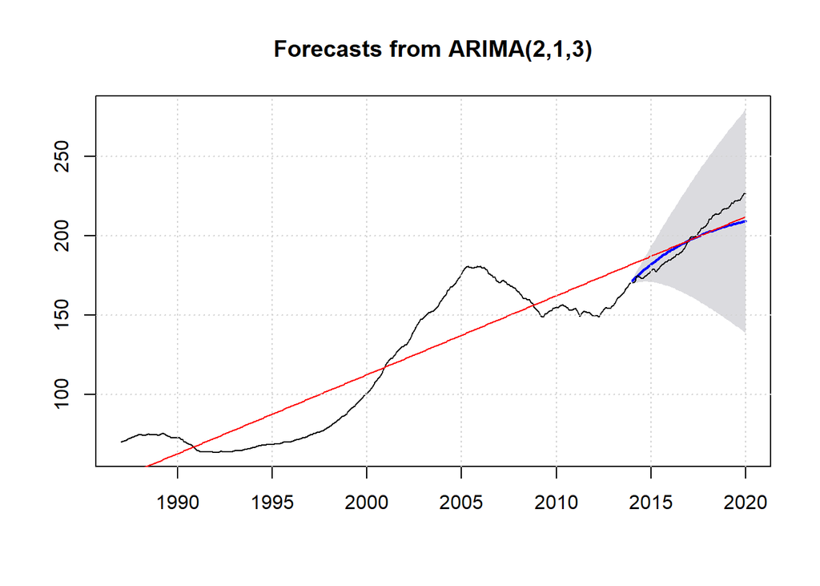

```r
BOXRSA.arima.fcast <- forecast(BOXRSA.arima,h=nValid,level=95)
plot(BOXRSA.arima.fcast)
lines(BOXRSA.valid)

# plot linear trend for comparison
lines(BOXRSA.trend$fitted.values,col="red")
grid()
```

```r
print(accuracy(BOXRSA.arima.fcast,BOXRSA.valid))
```

```
##                      ME      RMSE      MAE        MPE     MAPE       MASE
## Training set 0.02864739 0.4821605 0.334002 0.03079894 0.279612 0.04873491
## Test set     2.36690844 7.9430300 6.543212 0.89895893 3.198143 0.95473333
##                     ACF1 Theil's U
## Training set -0.01954551        NA
## Test set      0.96335664  6.606092
```

### Part Four: Basic Holt filter method

This method takes into account the trend of the dataset. Since our time series has an obvious trend, I tried Holt’s linear trend model. Empirical evidence indicates that these methods tend to over-forecast, especially for longer forecast horizons. Motivated by this observation, Gardner & McKenzie (1985) introduced a parameter that “dampens” the trend to a flat line sometime in the future. The RMSE is 0.540 for training set and 23.940 for validation set.

```r
ses.pred <- holt(BOXRSA.train,damped = TRUE, h=nValid, level=95)
summary(ses.pred)
```

```
##
## Forecast method: Damped Holt's method
##
## Model Information:
## Damped Holt's method
##
## Call:
##  holt(y = BOXRSA.train, h = nValid, damped = TRUE, level = 95)
##
##   Smoothing parameters:
##     alpha = 0.9999
##     beta  = 0.6075
##     phi   = 0.9083
##
##   Initial states:
##     l = 69.6641
##     b = 0.4658
##
##   sigma:  0.544
##
##      AIC     AICc      BIC
## 1485.417 1485.682 1508.101
##
## Error measures:
##                      ME      RMSE       MAE        MPE      MAPE       MASE
## Training set 0.04677606 0.5397873 0.3698376 0.04393108 0.3032248 0.05396375
##                    ACF1
## Training set 0.02242805
##
## Forecasts:
##          Point Forecast    Lo 95    Hi 95
## Jan 2014       171.2538 170.1876 172.3200
## Feb 2014       172.1184 170.1501 174.0867
## Mar 2014       172.9038 169.9600 175.8475
## Apr 2014       173.6171 169.6399 177.5943
## May 2014       174.2651 169.2130 179.3173
## Jun 2014       174.8537 168.6985 181.0089
## Jul 2014       175.3884 168.1124 182.6643
## Aug 2014       175.8740 167.4677 184.2803
## Sep 2014       176.3152 166.7752 185.8552
```

[output cut: 49 more lines]

```
## Nov 2018       180.6516 130.6828 230.6203
## Dec 2018       180.6549 130.1317 231.1780
## Jan 2019       180.6578 129.5861 231.7296
## Feb 2019       180.6605 129.0457 232.2754
## Mar 2019       180.6630 128.5105 232.8155
## Apr 2019       180.6652 127.9803 233.3502
## May 2019       180.6673 127.4551 233.8794
## Jun 2019       180.6691 126.9347 234.4036
## Jul 2019       180.6708 126.4189 234.9226
## Aug 2019       180.6723 125.9078 235.4368
## Sep 2019       180.6737 125.4012 235.9462
## Oct 2019       180.6749 124.8989 236.4509
## Nov 2019       180.6761 124.4009 236.9512
## Dec 2019       180.6771 123.9072 237.4470
## Jan 2020       180.6780 123.4175 237.9386
```

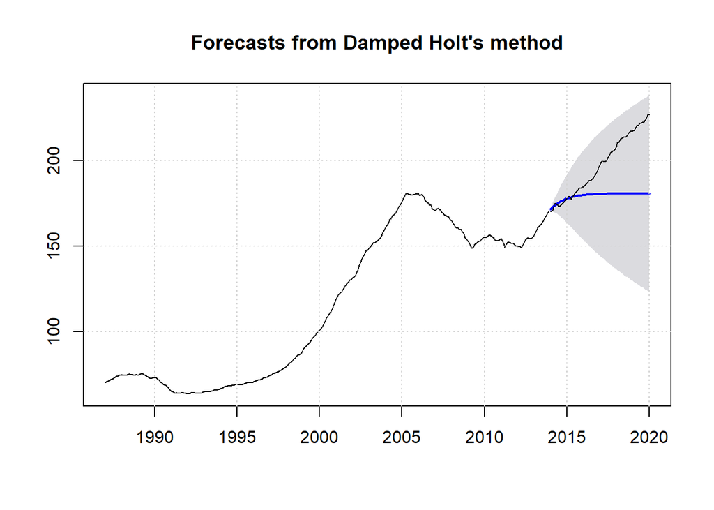

```r
plot(ses.pred)
lines(BOXRSA.valid)
grid()
```

```r
print(accuracy(ses.pred,BOXRSA.valid))
```

```
##                       ME       RMSE        MAE        MPE      MAPE       MASE
## Training set  0.04677606  0.5397873  0.3698376 0.04393108 0.3032248 0.05396375
## Test set     17.80847494 23.9397715 18.2710184 8.38900398 8.6553346 2.66596128
##                    ACF1 Theil's U
## Training set 0.02242805        NA
## Test set     0.96663443  19.57093
```

### Part Five: Baseline

Finally, we use some baseline forecasting model to see how our models work and to find out the best model.

#### Simple Linear Model

Since this time series has an obvious trend and with no seasonality, it’s reasonable to have a try on linear forecast.

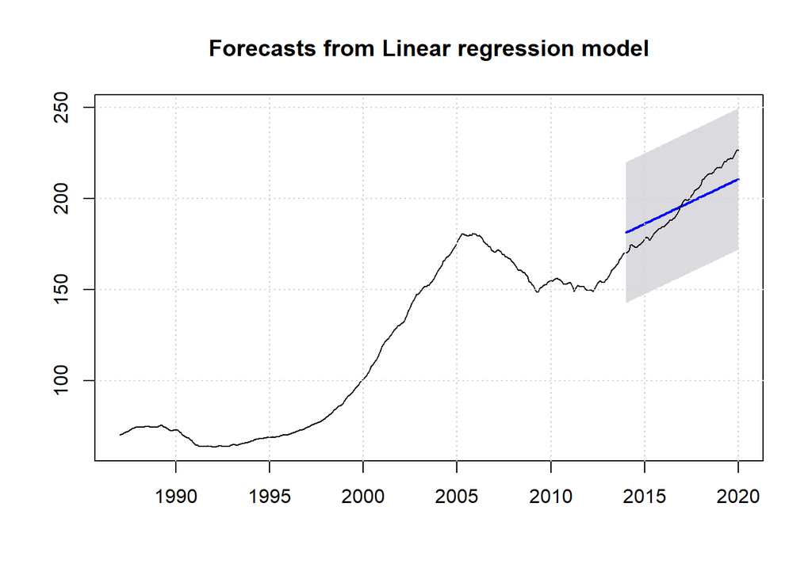

```r
# First, estimate addiive trend/seasonal filter
train.lm <- tslm(BOXRSA.train ~ trend )
# Now, build forecasts for validation periods
train.lm.pred <- forecast(train.lm, h=nValid, level=95)

# plot all the results
plot(train.lm.pred)
lines(BOXRSA.valid)

grid()
```

```r
print(accuracy(train.lm.pred,BOXRSA.valid))
```

```
##                        ME      RMSE       MAE         MPE      MAPE     MASE
## Training set 2.494045e-15 19.445196 17.212982 -2.94316498 16.573685 2.511581
## Test set     9.576603e-01  9.090857  8.261618  0.08274007  4.173586 1.205469
##                   ACF1 Theil's U
## Training set 0.9967236        NA
## Test set     0.9638673  7.890545
```

#### Naive method & drift method

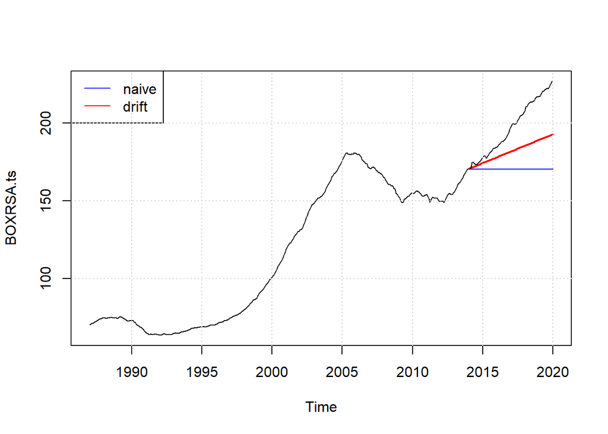

```r
# Find multiple naive forecasts
BOXRSA.lm.naive <-  naive(BOXRSA.train, h = nValid, level = 0)
BOXRSA.lm.drift <-  rwf(BOXRSA.train, h = nValid, drift = TRUE, level = 0)

# plot the forecast in the validation period
plot(BOXRSA.ts)

# plot data in the validation period
lines(BOXRSA.lm.naive$mean,col="blue")
lines(BOXRSA.lm.drift$mean,col="red",lwd=2)
lines(BOXRSA.valid,lty="dashed")
legend("topleft",col=c("blue","red"),legend=c("naive","drift"),lty=1)
grid()
```

```r
print(accuracy(BOXRSA.lm.naive,BOXRSA.valid))
```

```
##                      ME       RMSE        MAE        MPE       MAPE      MASE
## Training set  0.3097058  0.8918631  0.6941125  0.2715356  0.5838199 0.1012794
## Test set     26.7851458 32.0339385 26.7871377 12.9015590 12.9027292 3.9085655
##                   ACF1 Theil's U
## Training set 0.7506755        NA
## Test set     0.9622136  26.52495
```

```r
print(accuracy(BOXRSA.lm.drift,BOXRSA.valid))
```

```
##                         ME       RMSE        MAE         MPE      MAPE
## Training set -4.223688e-15  0.8363624  0.6439652 -0.04076415 0.5455505
## Test set      1.532603e+01 18.9239014 15.3488525  7.33637373 7.3497695
##                    MASE      ACF1 Theil's U
## Training set 0.09396227 0.7506755        NA
## Test set     2.23958213 0.9634111  15.59809
```

After that, I created a table and compared all the validation RMSEs. So it’s clear that ARIMA(d=1) is the best model to forecast MA-Boston Home Price Index with a RMSE only 7.943.

```r
library(dplyr)
library(kableExtra)
RMSE <- data.frame('Model'=c("Naive","Drift","Holt filter","ARIMA (d=1)","Linear"),'Validation_RMSE'= c(accuracy(BOXRSA.lm.naive,BOXRSA.valid)[2,2],accuracy(BOXRSA.lm.drift,BOXRSA.valid)[2,2],accuracy(ses.pred,BOXRSA.valid)[2,2],accuracy(BOXRSA.arima.fcast,BOXRSA.valid)[2,2],accuracy(train.lm.pred,BOXRSA.valid)[2,2]))

RMSE <- RMSE %>% arrange(Validation_RMSE)

RMSE %>%
  knitr::kable(digits=3,align='c')%>%
  kable_styling(full_width = F)
```

| Model | Validation_RMSE |
| --- | --- |
| ARIMA (d=1) | 7.943 |
| Linear | 9.091 |
| Drift | 18.924 |
| Holt filter | 23.940 |
| Naive | 32.034 |

So it’s clear that ARIMA(d=1) is the best model to forecast MA-Boston Home Price Index with a RMSE only 7.943.

### Part Six: Compare ARIMA with Simple Linear model: Diebold/Mariano

Here we use Diebold/Mariano test to verify whether ARIMA is the best model. I compared ARIMA with all other models, and Table 2 shows the p-value of these Diebold/Mariano tests.

```r
# This section code suggests how you would probably use the Diebold/Mariano test in practice
# We want to know if the firm should bother to shift to ARIMA forecasting from other models
# A one sided test is most appropriate here, with the alternative = less
# A rejection (low p-value) means you should shift to the ARIMA forecast

print("Diebold/Mariano ARIMA versus naive test: alternative = less")
```

```
## [1] "Diebold/Mariano ARIMA versus naive test: alternative = less"
```

```r
print(dm.test(residuals(BOXRSA.arima.fcast),residuals(ses.pred),alternative="less"))
```

```
##
##  Diebold-Mariano Test
##
## data:  residuals(BOXRSA.arima.fcast)residuals(ses.pred)
## DM = -3.0142, Forecast horizon = 1, Loss function power = 2, p-value =
## 0.00139
## alternative hypothesis: less
```

```r
DM <- data.frame('Model'=c("Naive","Drift","Holt filter","Linear"),'p.value'= c(dm.test(residuals(BOXRSA.arima.fcast),residuals(BOXRSA.lm.naive),alternative="less")$p.value,
  dm.test(residuals(BOXRSA.arima.fcast),residuals(BOXRSA.lm.drift),alternative="less")$p.value,
  dm.test(residuals(BOXRSA.arima.fcast),residuals(ses.pred),alternative="less")$p.value,
  dm.test(residuals(BOXRSA.arima.fcast),residuals(train.lm.pred),alternative="less")$p.value))

DM <- DM %>% arrange(desc(p.value))

DM %>%
  knitr::kable(align='c')%>%
  kable_styling(full_width = F)
```

| Model | p.value |
| --- | --- |
| Holt filter | 0.0013903 |
| Drift | 0.0000000 |
| Naive | 0.0000000 |
| Linear | 0.0000000 |

As shown in the table, p-values are all very small, so we can say that it is statistically significant that ARIMA model outperforms all other models.